# Gamma Distribution

April 27, 2020

## Chapter 7

**Section 7.2**

## Gamma Function

*Definition.*

The **Gamma function**, denoted \( \small \Gamma(\alpha) \) is defined as

\[ \large \Gamma(\alpha) = \int\limits_{0}^{\infty}t^{\alpha-1}e^{-t}dt\quad\text{for }\alpha >0 \]

*Solutions.*

\[ \Gamma(1) = \int\limits_{0}^{\infty}e^{-t}dt = -e^{-t}|_{0}^{\infty} = -(0-1) = 1 \]

\[ \Gamma(2) = 1 \quad \quad \Gamma(1/2) = \sqrt{\pi} \]

### Properties of the Gamma Function

(1) \[ \Gamma(\alpha) = (\alpha - 1)\Gamma(\alpha - 1) \quad \text{for } \alpha > 1 \]

*Examples.*

\[ \begin{aligned} \Gamma(3/2) = (1/2)\Gamma(1/2) = \sqrt{\pi}/2 \\ \Gamma(5/2) = (3/2)\Gamma(3/2) = 3\sqrt{\pi}/4 \end{aligned} \]

*Proof.*

\[ \begin{aligned} \Gamma(\alpha) &= \int\limits_{0}^{\infty}t^{\alpha-1}e^{-t}dt \quad \#\text{by parts} \begin{cases} u = t^{\alpha-1} &\quad du = (\alpha-1)t^{\alpha-2}dt \\ dv = e^{-t}dt&\quad v = -e^{-t}\end{cases} \\ &=-t^{\alpha-1}e^{-t}|_0^{\infty} + \int\limits_{0}^{\infty}(\alpha-1)t^{\alpha-2}e^{-t}dt = (\alpha-1)\int\limits_{0}^{\infty}t^{(\alpha-1)-1}e^{-t}dt = (\alpha-1)\Gamma(\alpha-1) \end{aligned} \]

(2) If \( \alpha \) is a positive integer.

\[ \Gamma(\alpha) = (\alpha-1)\Gamma(\alpha-1) = (\alpha-1)(\alpha-2)\Gamma(\alpha-2) = \: ...\: = (\alpha-1)(\alpha-2)\cdot\cdot\cdot2\cdot1\cdot\Gamma(1) \]

Thus,

\[ \Gamma(\alpha) = (\alpha-1)! \]

## Gamma Distribution

*Definition.*

A random variable \( \small X \) is said to have a **Gamma distribution** with parameters \( \small \alpha > 0 \) and \( \small \lambda > 0 \), if the pdf of \( \small X \) is given by

\[ \large f(x) = \frac{\lambda^{\alpha}}{\Gamma(\alpha)}x^{\alpha-1}e^{-\lambda x}1_{(0,\infty)}(x) \]

*Notes.*

Defines a family of distributions for non-negative random variables.

Generalization of \( \small Exp(\lambda) \)

- Let \( \small X \sim Gamma(1, \lambda) \)

Chi-Squared distribution

- Let \( \small X \sim Gamma(n/2, 1/2) \)

### Gamma pdf

\[ \large f(x) = \frac{\lambda^{\alpha}}{\Gamma(\alpha)}x^{\alpha-1}e^{-\lambda x}1_{(0,\infty)}(x) \]

Does \( \small f(x) \) represent a valid pdf?

(1) \( \small f(x) \) is non-negative

(2) \[ \int\limits_{-\infty}^{\infty}f(x)dx = \frac{\lambda^{\alpha}}{\Gamma(\alpha)}\int\limits_{0}^{\infty}x^{\alpha-1}e^{-\lambda x}dx \]

Substitue \( \small y = \lambda x \implies dy = \lambda dx \implies dx = (1/\lambda) dy \). Then,

\[ \begin{aligned} &\frac{\lambda^{\alpha}}{\Gamma(\alpha)}\int\limits_{0}^{\infty}x^{\alpha-1}e^{-\lambda x}dx = \frac{\lambda^{\alpha}}{\Gamma(\alpha)}\int\limits_{0}^{\infty}\left(\frac{y}{\lambda}\right)^{\alpha-1}e^{-y}\left(\frac{1}{\lambda}\right)dy \\ =&\frac{\lambda^{\alpha}}{\Gamma(\alpha)}\frac{1}{\lambda^{\alpha}}\int\limits_{0}^{\infty}y^{\alpha-1}e^{-y}dy \quad \text{ by definition } \Gamma(\alpha) = \int\limits_{0}^{\infty}y^{\alpha-1}e^{-y}dy \\ =& \frac{\lambda^{\alpha}}{\Gamma(\alpha)}\frac{\Gamma(\alpha)}{\lambda^{\alpha}} = 1 \end{aligned} \]

### Properties of Gamma distribution

\[ \large f(x) = \frac{\lambda^{\alpha}}{\Gamma(\alpha)}x^{\alpha-1}e^{-\lambda x}1_{(0,\infty)}(x) \]

(1) \[ \lim\limits_{x\to 0}f(x) = f(0) = \begin{cases}0 & \alpha > 1 \\ \lambda & \alpha = 1 \\ \infty & 0 < \alpha < 1 \end{cases} \]

(2) As \( \small x \to \infty \), \( \small f(x) \to 0 \).

(3) Critical points of \( \small f(x) \)?

\[ \begin{aligned} \frac{d}{dx}f(x) &= \frac{\lambda^{\alpha}}{\Gamma(\alpha)}(\alpha-1)x^{\alpha-2}e^{-\lambda x} + \frac{\lambda^{\alpha}}{\Gamma(\alpha)}x^{\alpha-1}(-\lambda)e^{-\lambda x} \\ &= \frac{\lambda^{\alpha}}{\Gamma(\alpha)}\left((\alpha-1)x^{\alpha-2} - \lambda x^{\alpha-1}\right)e^{-\lambda x} \end{aligned} \]

Setting \( \small f'(x) = 0 \), then we acheitve critical points…

- If \( \small \alpha > 2 \), then \( x=0 \) is a critical point.
- If \( \small \alpha \geq 1 \), then \( x = \frac{\alpha-1}{\lambda} \) is a critical point.

### Properties of Gamma distribution

\[ \large f(x) = \frac{\lambda^{\alpha}}{\Gamma(\alpha)}x^{\alpha-1}e^{-\lambda x}1_{(0,\infty)}(x) \]

What does this imply about \( \small f(x) \)?

- \( \small f(x) \) has a maximum at \( x = \frac{\alpha - 1}{\lambda} \) if \( \alpha \geq 1 \).
- \( \small f(x) \) has a vertical asymptote as \( \small x \to 0 \) when \( \alpha < 1 \).

[figure not shown]

This distribution explores the positive real plane. Many shapes are possible.

### Gamma Distribution in R

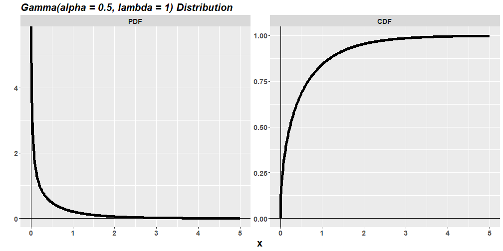

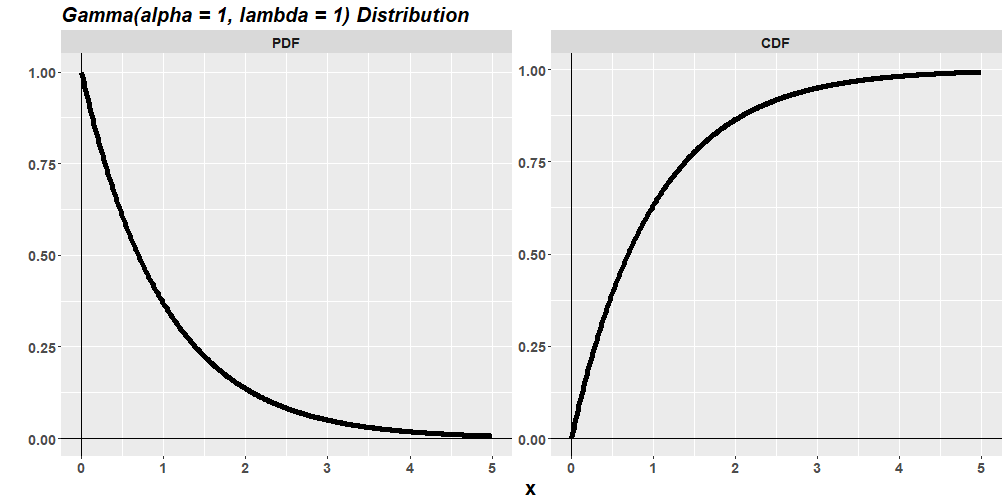

```r
dgamma(x, alpha, lambda) #pdf
pgamma(x, alpha, lambda) #cdf
qgamma(q, alpha, lambda) #quantile
```

### Gamma Distribution in R

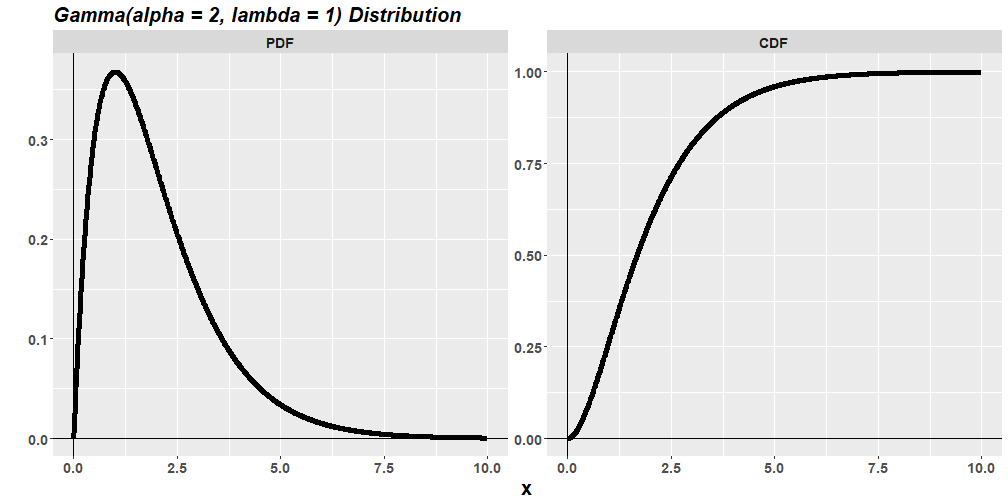

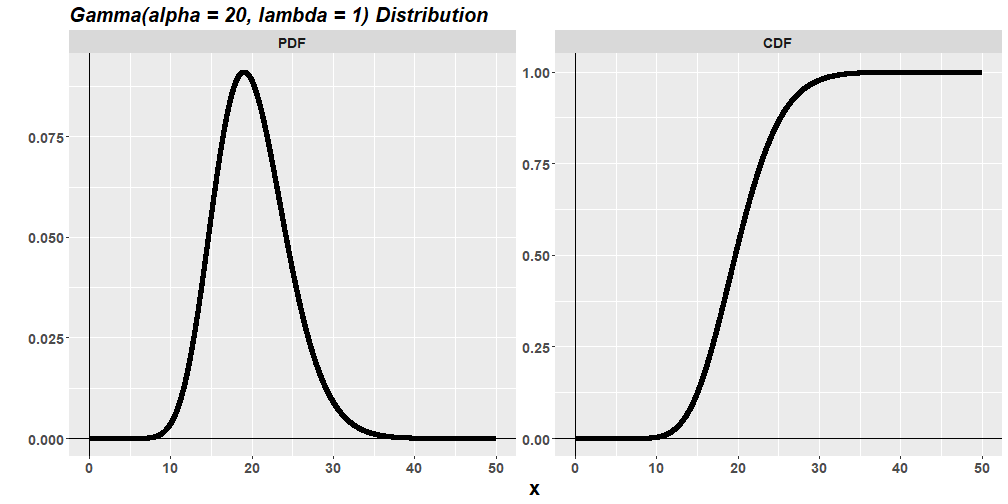

## Gamma Distribution

*Results.*

Let \( \small X \sim Gamma(\alpha, \lambda) \), then

(1) cdf has no general closed form (does exist when \( \small \alpha \) is a positive integer)

(2) \[ E[X] = \frac{\alpha}{\lambda} \]

(2) \[ V[X] = \frac{\alpha}{\lambda^2} \]

### Proof.

Consider \( \small X \sim Gamma(\alpha, \lambda) \). Let \( \small k > 0 \).

\[ \begin{aligned} E[X^k] &= \int\limits_{-\infty}^{\infty}x^kf(x)dx = \frac{\lambda^{\alpha}}{\Gamma(\alpha)}\int\limits_{0}^{\infty}x^kx^{\alpha-1}e^{-\lambda x}dx \\ &= \frac{\lambda^{\alpha}}{\Gamma(\alpha)}\int\limits_{0}^{\infty}x^{\alpha+k-1}e^{-\lambda x}dx \end{aligned} \]

Work to make the integral look like another Gamma distribution. This is a common technique to use in the solution of advanced statistics problems.

\[ \begin{aligned} &= \frac{\lambda^{\alpha}}{\Gamma(\alpha)}\frac{\Gamma(\alpha + k)}{\lambda^{\alpha+k}}\int\limits_{0}^{\infty}\frac{\lambda^{\alpha+k}}{\Gamma(\alpha + k)}x^{\alpha+k-1}e^{-\lambda x}dx \end{aligned} \]

Recognize that the integral is equivalent to that of a \( \small Gamma(\alpha + k, \lambda) \) distribution. We are integrating over all possible values, thus the integral is \( 1 \). Then,

\[ E[X^k] = \frac{\Gamma(\alpha + k)}{\Gamma(\alpha)}\frac{\lambda^{\alpha}}{\lambda^{\alpha+k}} = \frac{\Gamma(\alpha + k)}{\Gamma(\alpha)}\frac{1}{\lambda^{k}} \]

Of which the expectation and variance are easily obtained.